# Project: tmdb-movies analysis

- Introduction
- Data Wrangling
- Exploratory Data Analysis
- Conclusions
- Limitations

## Introduction

### Dataset Description

This dataset contains information of approximatley 10,000 movie titles collected from the movie database (TMDb). The information provided is the popularity of the movie, budget invested for the movie, revenue and profit from the movie, title, cast members, director, homepage, tagline, keywords, overview, runtime, genres, production_companies, release_date, vote_count, vote_average and release_year.

### Question(s) for Analysis

> **Research Question 1 (Profit Change in regard to years)**

> **Research Question 2 (Movies with the highest and lowest profit)**

> **Research Question 3 (Are average votes getting better by the years?)**

> **Research Question 4 ( What are the most frequent elements in each categorical section )**

> **Research Question 5 ( Do Higher budget movies produce higher profit ? )**

> **Research Question 6 ( Does Popularity influence profit and is it influenced by the runtime? )**

```python
import numpy as np
import pandas as pd
import matplotlib
matplotlib.style.use('ggplot')
import seaborn as sns
import matplotlib.pyplot as plt
from datetime import datetime as dt
%matplotlib inline
```

## Data Wrangling

### General Properties

```python
#  reading the csv file
df=pd.read_csv("tmdb-movies.csv")
df.info();
```

```
<class 'pandas.core.frame.DataFrame'>
RangeIndex: 10866 entries, 0 to 10865
Data columns (total 21 columns):
id                      10866 non-null int64
imdb_id                 10856 non-null object
popularity              10866 non-null float64
budget                  10866 non-null int64
revenue                 10866 non-null int64
original_title          10866 non-null object
cast                    10790 non-null object
homepage                2936 non-null object
director                10822 non-null object
tagline                 8042 non-null object
keywords                9373 non-null object
overview                10862 non-null object
runtime                 10866 non-null int64
genres                  10843 non-null object
production_companies    9836 non-null object
release_date            10866 non-null object
vote_count              10866 non-null int64
vote_average            10866 non-null float64
release_year            10866 non-null int64
budget_adj              10866 non-null float64
revenue_adj             10866 non-null float64
dtypes: float64(4), int64(6), object(11)
memory usage: 1.7+ MB
```

```python
#checking for empty rows and missing data
df.isna().sum()
```

```
id                         0
imdb_id                   10
popularity                 0
budget                     0
revenue                    0
original_title             0
cast                      76
homepage                7930
director                  44
tagline                 2824
keywords                1493
overview                   4
runtime                    0
genres                    23
production_companies    1030
release_date               0
vote_count                 0
vote_average               0
release_year               0
budget_adj                 0
revenue_adj                0
dtype: int64
```

```python
#getting to know the dataset
df.shape
```

```
(10866, 21)
```

```python
#deciphering the numerical tags on each numerical column
df.describe()
```

|  | id | popularity | budget | revenue | runtime | vote_count | vote_average | release_year | budget_adj | revenue_adj |
| --- | --- | --- | --- | --- | --- | --- | --- | --- | --- | --- |
| count | 10866.000000 | 10866.000000 | 1.086600e+04 | 1.086600e+04 | 10866.000000 | 10866.000000 | 10866.000000 | 10866.000000 | 1.086600e+04 | 1.086600e+04 |
| mean | 66064.177434 | 0.646441 | 1.462570e+07 | 3.982332e+07 | 102.070863 | 217.389748 | 5.974922 | 2001.322658 | 1.755104e+07 | 5.136436e+07 |
| std | 92130.136561 | 1.000185 | 3.091321e+07 | 1.170035e+08 | 31.381405 | 575.619058 | 0.935142 | 12.812941 | 3.430616e+07 | 1.446325e+08 |
| min | 5.000000 | 0.000065 | 0.000000e+00 | 0.000000e+00 | 0.000000 | 10.000000 | 1.500000 | 1960.000000 | 0.000000e+00 | 0.000000e+00 |
| 25% | 10596.250000 | 0.207583 | 0.000000e+00 | 0.000000e+00 | 90.000000 | 17.000000 | 5.400000 | 1995.000000 | 0.000000e+00 | 0.000000e+00 |
| 50% | 20669.000000 | 0.383856 | 0.000000e+00 | 0.000000e+00 | 99.000000 | 38.000000 | 6.000000 | 2006.000000 | 0.000000e+00 | 0.000000e+00 |
| 75% | 75610.000000 | 0.713817 | 1.500000e+07 | 2.400000e+07 | 111.000000 | 145.750000 | 6.600000 | 2011.000000 | 2.085325e+07 | 3.369710e+07 |
| max | 417859.000000 | 32.985763 | 4.250000e+08 | 2.781506e+09 | 900.000000 | 9767.000000 | 9.200000 | 2015.000000 | 4.250000e+08 | 2.827124e+09 |

```python
#seems like some categorical column values need to be splitted on (|)
df['production_companies']
```

```
0        Universal Studios|Amblin Entertainment|Legenda...
1        Village Roadshow Pictures|Kennedy Miller Produ...
2        Summit Entertainment|Mandeville Films|Red Wago...
3                Lucasfilm|Truenorth Productions|Bad Robot
4        Universal Pictures|Original Film|Media Rights ...
                               ...
10861                                    Bruce Brown Films
10862    Cherokee Productions|Joel Productions|Douglas ...
10863                                              Mosfilm
10864                              Benedict Pictures Corp.
10865                                            Norm-Iris
Name: production_companies, Length: 10866, dtype: object
```

```python
df['director']
```

```
0           Colin Trevorrow
1             George Miller
2          Robert Schwentke
3               J.J. Abrams
4                 James Wan
                ...
10861           Bruce Brown
10862    John Frankenheimer
10863        Eldar Ryazanov
10864           Woody Allen
10865      Harold P. Warren
Name: director, Length: 10866, dtype: object
```

```python
#sum of rows that contain (|)
df.director.astype(str).apply(lambda x : "|" in x).sum()
```

```
754
```

```python
df.cast.astype(str).apply(lambda x : "|" in x).sum()
```

```
10646
```

```python
df.production_companies.astype(str).apply(lambda x : "|" in x).sum()
```

```
6396
```

### Data Cleaning

```python
#removing unnecessary columns to our study and getting rid of duplicates
df.drop(columns=['homepage','tagline','keywords','overview','budget_adj','revenue_adj','imdb_id'],inplace=True)
df.drop_duplicates(inplace=True)
df.info()
```

```
<class 'pandas.core.frame.DataFrame'>
Int64Index: 10865 entries, 0 to 10865
Data columns (total 14 columns):
id                      10865 non-null int64
popularity              10865 non-null float64
budget                  10865 non-null int64
revenue                 10865 non-null int64
original_title          10865 non-null object
cast                    10789 non-null object
director                10821 non-null object
runtime                 10865 non-null int64
genres                  10842 non-null object
production_companies    9835 non-null object
release_date            10865 non-null object
vote_count              10865 non-null int64
vote_average            10865 non-null float64
release_year            10865 non-null int64
dtypes: float64(2), int64(6), object(6)
memory usage: 1.2+ MB
```

```python
#The release date had to be restructred in a datetime format for more precise data analysis.
df.release_date=pd.to_datetime(df['release_date'])
df.release_date=df.release_date.apply(lambda x : x.strftime('%Y-%m-%d').replace("20","19") if (x.strftime('%Y')>'2021') else x.strftime('%Y-%m-%d'))
df.release_date=pd.to_datetime(df['release_date'])
df.release_date
```

```
0       2015-06-09
1       2015-05-13
2       2015-03-18
3       2015-12-15
4       2015-04-01
           ...
10861   1966-06-15
10862   1966-12-21
10863   1966-01-01
10864   1966-11-02
10865   1966-11-15
Name: release_date, Length: 10865, dtype: datetime64[ns]
```

```python
#filling columns of categorical values with 'Unknown' and columns with 0 numerical values to NaN so it doesnt influence mathematical computation
df[['cast','director','production_companies','genres']]=df[['cast','director','production_companies','genres']].fillna('Unknown')
df['budget']=df['budget'].replace(0,np.nan)
df['revenue']=df['revenue'].replace(0,np.nan)
df.info()
```

```
<class 'pandas.core.frame.DataFrame'>
Int64Index: 10865 entries, 0 to 10865
Data columns (total 14 columns):
id                      10865 non-null int64
popularity              10865 non-null float64
budget                  5169 non-null float64
revenue                 4849 non-null float64
original_title          10865 non-null object
cast                    10865 non-null object
director                10865 non-null object
runtime                 10865 non-null int64
genres                  10865 non-null object
production_companies    10865 non-null object
release_date            10865 non-null datetime64[ns]
vote_count              10865 non-null int64
vote_average            10865 non-null float64
release_year            10865 non-null int64
dtypes: datetime64[ns](1), float64(4), int64(4), object(5)
memory usage: 1.2+ MB
```

```python
#adding a new column which indicates the profit and figuring the number of rows since we know that budget and revenue contain False values initially
df['profit']=df['revenue']-df['budget']
df.profit.count()
```

```
3854
```

```python
#revising our cleaning results
df.info()
```

```
<class 'pandas.core.frame.DataFrame'>
Int64Index: 10865 entries, 0 to 10865
Data columns (total 15 columns):
id                      10865 non-null int64
popularity              10865 non-null float64
budget                  5169 non-null float64
revenue                 4849 non-null float64
original_title          10865 non-null object
cast                    10865 non-null object
director                10865 non-null object
runtime                 10865 non-null int64
genres                  10865 non-null object
production_companies    10865 non-null object
release_date            10865 non-null datetime64[ns]
vote_count              10865 non-null int64
vote_average            10865 non-null float64
release_year            10865 non-null int64
profit                  3854 non-null float64
dtypes: datetime64[ns](1), float64(5), int64(4), object(5)
memory usage: 1.3+ MB
```

## Exploratory Data Analysis

### Research Question 1 (Profit Change in regard to years)

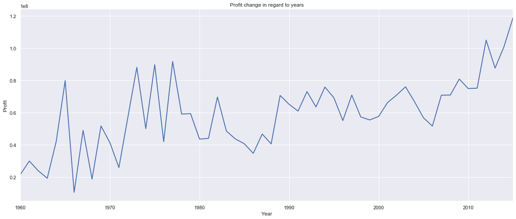

```python
#Explore how the growth of the industry has influenced the mean profit at each year

profit_df=df.groupby('release_year')['profit'].mean().plot(figsize=(20,8),lw=2,title='Profit change in regard to years')
profit_df.set_xlabel('Year')
profit_df.set_ylabel('Profit')
```

### Research Question 2 (Movies with the highest and lowest profit)

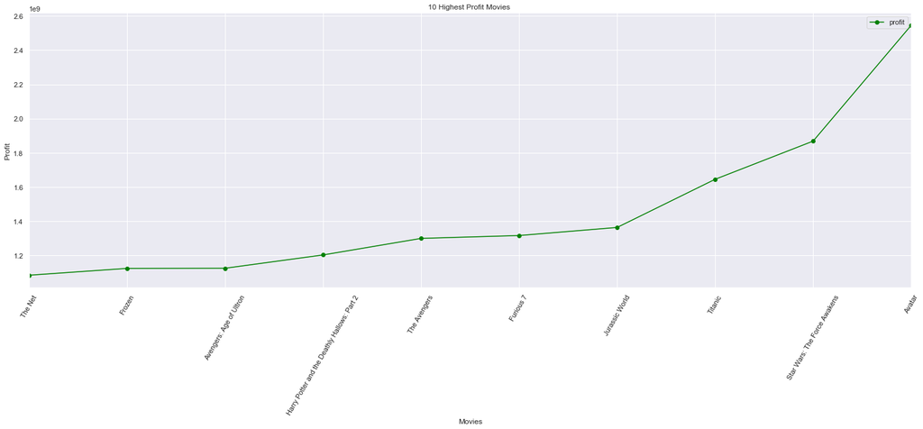

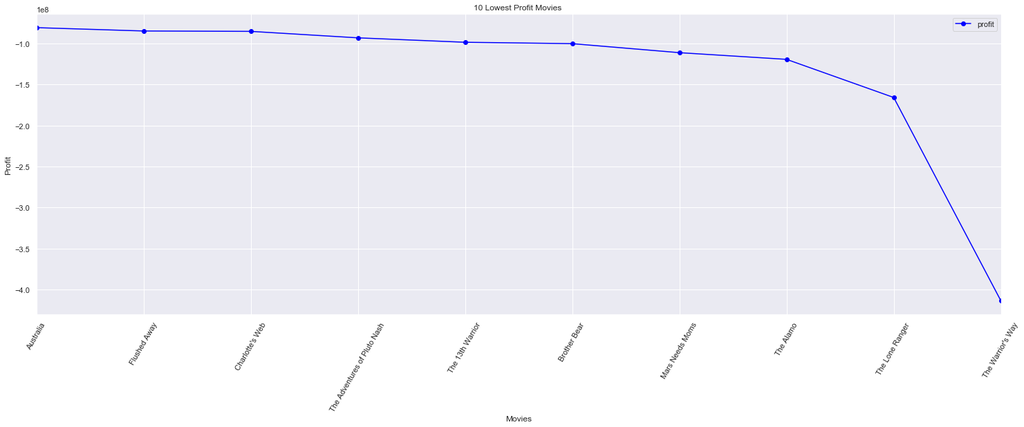

```python
#Exploring titles with most and lowest profit(loss)

maxmin_df=df.copy()
High=maxmin_df[maxmin_df['profit'].notnull()].sort_values(by=['profit'],ascending=True).tail(10)
Low=maxmin_df[maxmin_df['profit'].notnull()].sort_values(by=['profit'],ascending=False).tail(10)
High=High.plot(x='original_title',y='profit',rot=60,figsize=(25,8),marker='o',color='green',title='10 Highest Profit Movies ')
Low=Low.plot(x='original_title',y='profit',rot=60,figsize=(25,8),marker='o',color='blue',title='10 Lowest Profit Movies ')
High.set_xlabel('Movies')
High.set_ylabel('Profit')
Low.set_xlabel('Movies')
Low.set_ylabel('Profit')
```

#### Multiple representation of top 10 and bottom 10 could have been implemented but a simple line with a marker at each movie signifies for the noticable difference between adjacent movies.

### Research Question 3 (Are average votes getting better by the years?)

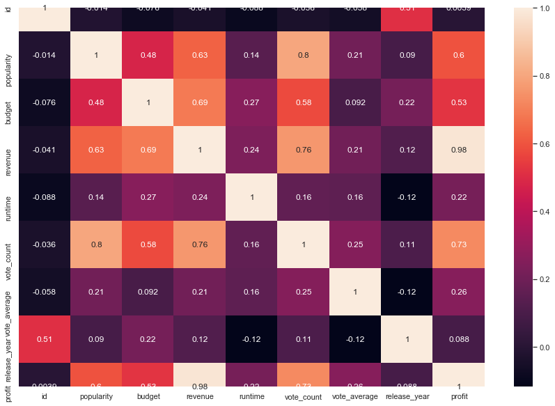

```python
#correlation betweem all numerical columns of our dataset
sns.set(rc = {'figure.figsize':(15,10)})
heat=sns.heatmap(df.corr(),annot=True)
```

#### A correlation heatmap matrix to show interaction of numerical columns and their respective data

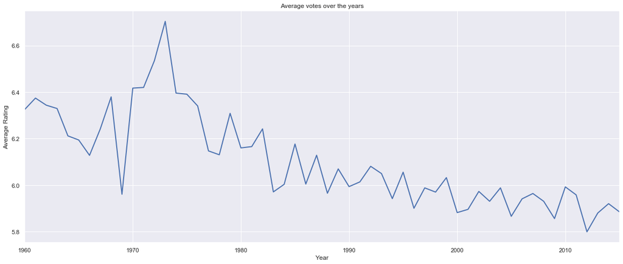

```python
# The average votes are decreasing year after year

Votes=df.groupby('release_year')['vote_average'].mean().plot(figsize=(20,8),lw=2,title='Average votes over the years')
Votes.set_xlabel('Year')
Votes.set_ylabel('Average Rating')
Votes.grid(color='white')
```

#### A simple line was plotted to show the descent of movie quality through ratings observed over the years

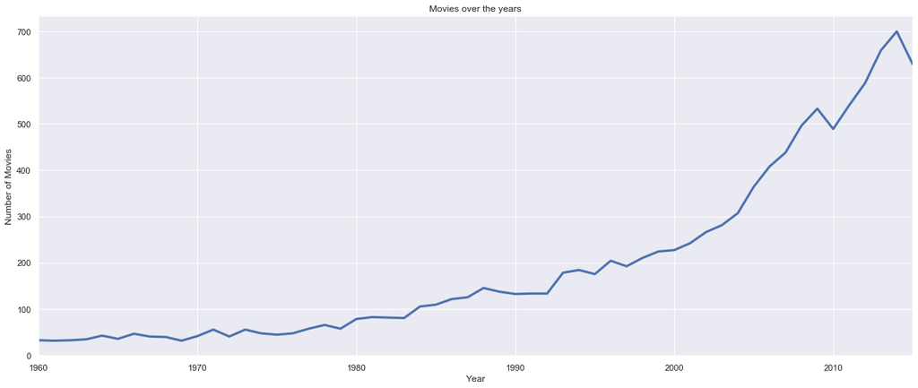

```python
#And a significant grouth in the number of titles and voters is noted
movies=df.groupby('release_year')['original_title'].count().plot(figsize=(20,8),lw=3,title='Movies over the years')
movies.set_xlabel('Year')
movies.set_ylabel('Number of Movies')
```

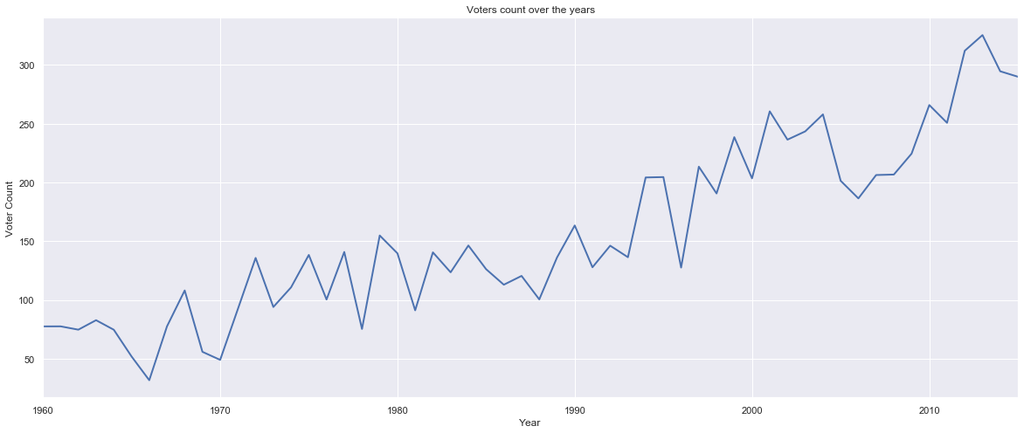

```python
#More people have interest in watching movies hence more people are capable of voting across the years

Voters=df.groupby('release_year')['vote_count'].mean().plot(figsize=(20,8),lw=2,title='Voters count over the years')
Voters.set_xlabel('Year')
Voters.set_ylabel('Voter Count')
```

#### A simple line was plotted to show the climbing trend observed over the years

### Research Question 4 ( What are the most frequent elements in each categorical section )

In each bar plot I have omitted the 'Unknown' constant which was added as a filler for NaN elements in categorical columns

Top 25 Director With Most Movies

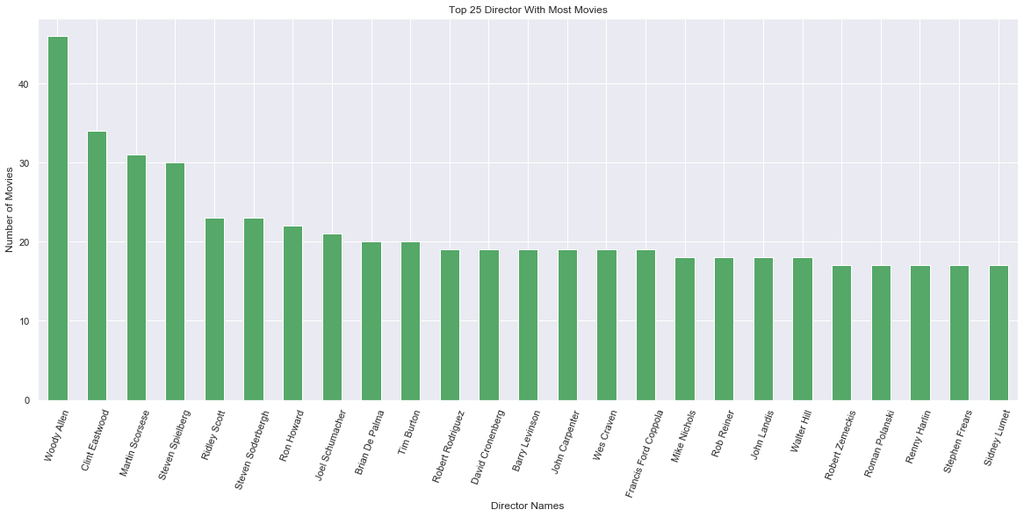

```python
directors_df=pd.Series(df[df['director']!='Unknown']['director'].str.cat(sep='|').split('|')).value_counts().head(25).plot.bar(figsize=(20,8),rot=70,color='g',title='Top 25 Director With Most Movies')
directors_df.set_ylabel('Number of Movies')
directors_df.set_xlabel('Director Names')
```

#### Bar charts are used since they are simple and easy to interpret the fixed number of works certain director has to his credit, for instance a director can't have 15.5 movies, they tolerate only an integer value.

Top 25 Actors with most appearances:

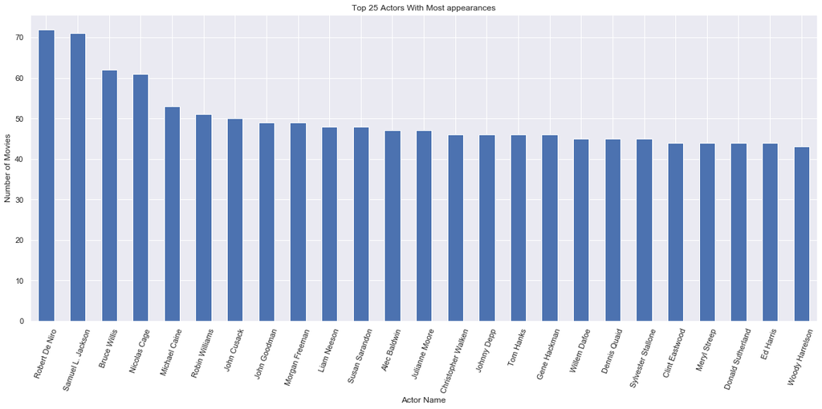

```python
Apperances_df=pd.Series(df[df['cast']!='Unknown']['cast'].str.cat(sep='|').split('|')).value_counts().head(25).plot.bar(figsize=(20,8),rot=70,title='Top 25 Actors With Most appearances')
Apperances_df.set_ylabel('Number of Movies')
Apperances_df.set_xlabel('Actor Name')
```

#### Similar to the directors Bar Chart, an actor can't have floating point number of movies, they tolerate only an integer value.

Genres with most movies:

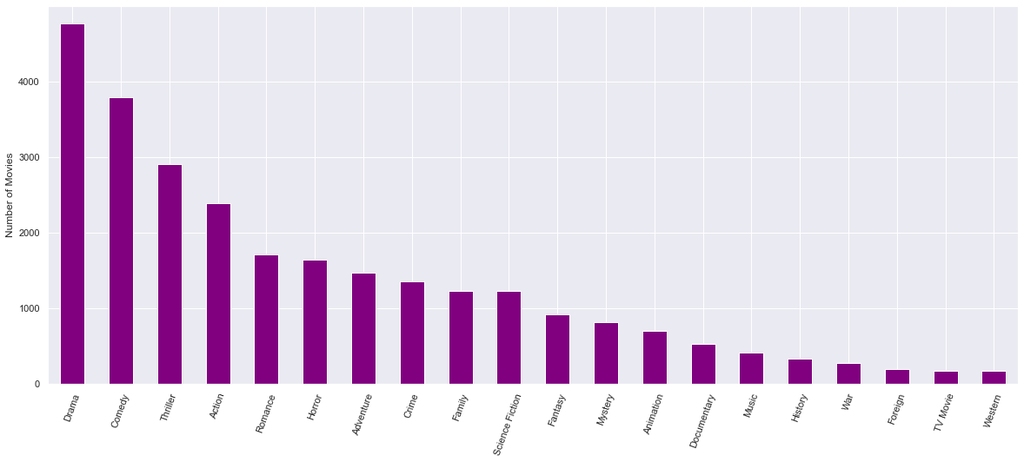

```python
genres_df=pd.Series(df[df['genres']!='Unknown']['genres'].str.cat(sep='|').split('|')).value_counts().plot.bar(figsize=(20,8),rot=70,color='purple')
genres_df.set_ylabel('Number of Movies')
```

#### Similar to the preceeding Bar Charts, Genres as a categorical nominal column it is better represented in this format.

Top 25 Production Studios:

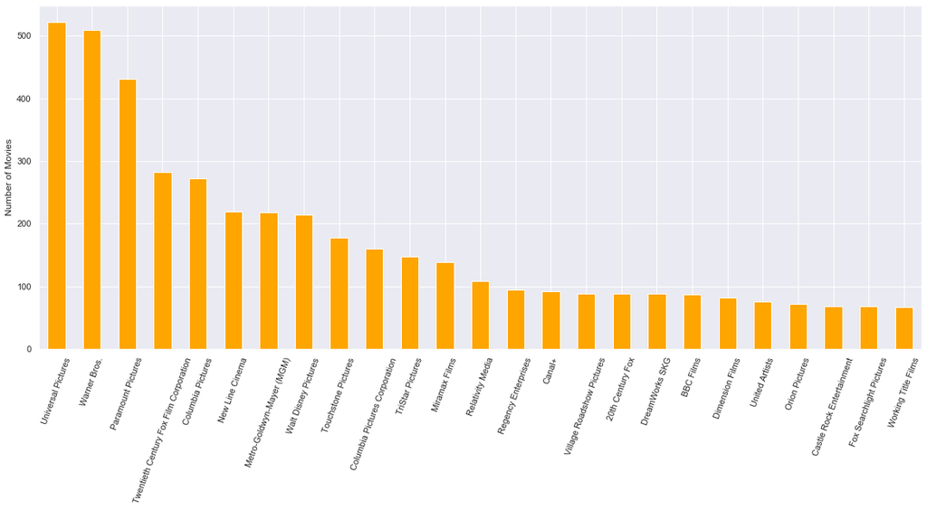

```python
pc_df=pd.Series(df[df['production_companies']!='Unknown']['production_companies'].str.cat(sep='|').split('|')).value_counts().head(25).plot.bar(figsize=(20,8),rot=70,color='orange')
pc_df.set_ylabel('Number of Movies')
```

#### Similar to the preceeding charts.

### Research Question 5 ( Do Higher budget movies produce higher profit ? )

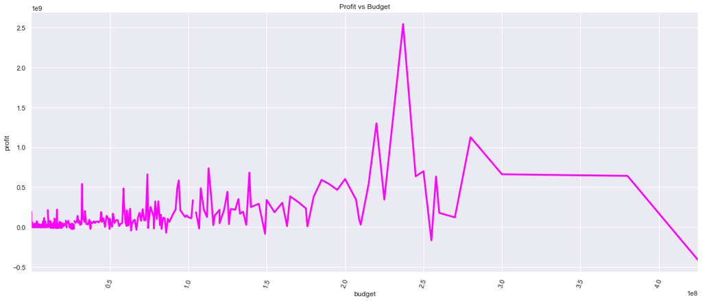

```python
bud_vs_prof=df.groupby('budget')['profit'].mean().plot(figsize=(20,8),rot=70,color='magenta',lw=3,title='Profit vs Budget')
bud_vs_prof.set_ylabel('profit')

# Not always the case since between 2.0 and 2.5 in budget their was a massive profit and loss was identified with budget greater than 4.0
```

#### This magenta line is suitable representative since it presents the fluctuations between profit and budget without plotting other variables, and it can be clearly observed that the higher the budget the greater the fluctuations, although this doesnt imply greater or lower profit per say .

### Research Question 6 ( Does Popularity influence profit and is it influenced by the runtime? )

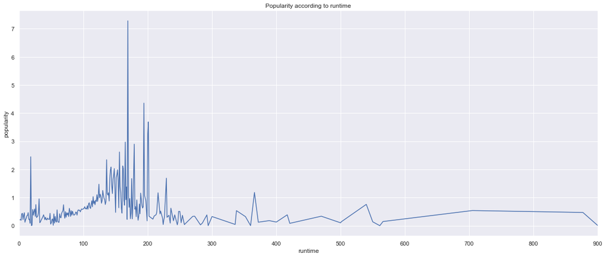

```python
#movies of length between 100 and 200 mins exhibit much more popularity than others
pops=df.groupby('runtime')['popularity'].mean().plot(figsize=(20,8),title='Popularity according to runtime')
pops.set_ylabel('popularity')
```

#### This line graph shows that most data points are heavy between a certain runtime

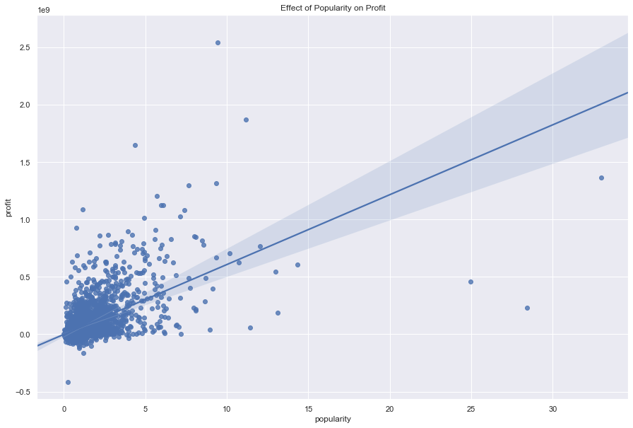

```python
#it is indicated that the more popular the movie the greater it tends to be profitable and also the correlation between them is 0.6 (not high but noticable)
popprf=sns.regplot(x=df['popularity'],y=df['profit'])
popprf.set_title('Effect of Popularity on Profit')
```

#### Using regplot we can deduce the correlation and density of our dataset in regard to both axes quite clearly.

## Conclusions

> **Research Question 1 (Profit Change in regard to years)** : From our given data set we have observed a rise in profit in the movie industry from 1960 onwards.

> **Research Question 2 (Movies with the highest and lowest profit)** : Avatar was the movie with most profit while The Warrior's Way suffered the greatest loss.

> **Research Question 3 (Are average votes getting better by the years?)** : The average votes are decreasing year after year And a significant growth in the number of titles and voters is noted since more people have interest in watching movies hence more people are capable of voting across the years. However due to the weak correlation between number of votes and average votes of 0.25 it is difficult to say that movie ratings are getting better or worse but it is safe to say their is a rise of number of movies and number of voters.

> **Research Question 4 ( What are the most frequent elements in each categorical section )** : CAST = Robert De Niro , PRODUCTION_COMPANIES = Universal Pictures , GENRES = Drama , DIRECTOR = Woddy Allen

> **Research Question 5 ( Do Higher budget movies produce higher profit ? )** : In our dataset it was not always the case since between 2.0 and 2.5 in budgetary terms their was a massive profit. While loss was identified with budget greater than 4.0, there was a correlation of 0.53 that seemed to affirm that the relationship wasn't strong and dependant on other variables altogether.

> **Research Question 6 ( Does Popularity influence profit and is it influenced by the runtime? )** : Movies of length between 100 and 200 mins exhibit much more popularity than others as well as popular movies tended to be more profitable and they do have a positive correlation of (0.6) which is reasonable and abids with common sense. The more Popular the movie the more the audience is attracted to the commotion and hence greater revenue resulting in a higher profit.

## Limitations

> **1** - Due to time constraints working on the project, I wanted to explore pandas, seaborne, matplotlib and python's capablities much more. This would've optimized my coding conduct and efficient use of functions. For instance I wanted to split genres, cast, production companies and directors into multiple rows. A movie with 3 genres and 2 cast members would require the same row to be repeated 6 TIMES so that the genres and cast do not coincide with each other at the same column section, or I would have come up with a whole different technique!

```
This would have provided me with decoupled rows that would have increased the size of the data set but would allow much more interesting insights to be extracted such as correlation between genres and popularity, cast member and profitabili-ty etc.
```

> **2** - Budget and revenue of certain movies could not be recalled and has impacted heavily its consequent rows being participants in major numerical anayltics.

> **3** - Time and location of movie screening or screening span could have provided more insights for deciding optimal timing to screen a title.

```python
from subprocess import call
call(['python', '-m', 'nbconvert', 'Investigate_a_Dataset.ipynb'])
```

```
0
```